# Lab 05 - Data Wrangling

John Chen

feb 07, 2024

# Learning goals

- Use the `merge()` function to join two datasets.
- Deal with missings and impute data.
- Identify relevant observations using `quantile()`.
- Practice your GitHub skills.

# Lab description

For this lab we will be dealing with the meteorological dataset `met`. In this case, we will use `data.table` to answer some questions regarding the `met` dataset, while at the same time practice your Git+GitHub skills for this project.

This markdown document should be rendered using `github_document` document.

# Part 1: Setup a Git project and the GitHub repository

1. Go to wherever you are planning to store the data on your computer, and create a folder for this project
2. In that folder, save [this template](https://github.com/JSC370/JSC370-2024/blob/main/labs/lab05/lab05-wrangling-gam.Rmd) as “README.Rmd”. This will be the markdown file where all the magic will happen.
3. Go to your GitHub account and create a new repository of the same name that your local folder has, e.g., “JSC370-labs”.
4. Initialize the Git project, add the “README.Rmd” file, and make your first commit.
5. Add the repo you just created on GitHub.com to the list of remotes, and push your commit to origin while setting the upstream.

Most of the steps can be done using command line:

```bash
# Step 1
cd ~/Documents
mkdir JSC370-labs
cd JSC370-labs

# Step 2
wget https://raw.githubusercontent.com/JSC370/JSC370-2024/main/labs/lab05/lab05-wrangling-gam.Rmd
mv lab05-wrangling-gam.Rmd README.Rmd
# if wget is not available,
curl https://raw.githubusercontent.com/JSC370/JSC370-2024/main/labs/lab05/lab05-wrangling-gam.Rmd --output README.Rmd

# Step 3
# Happens on github

# Step 4
git init
git add README.Rmd
git commit -m "First commit"

# Step 5
git remote add origin git@github.com:[username]/JSC370-labs
git push -u origin master
```

You can also complete the steps in R (replace with your paths/username when needed)

```r
# Step 1
setwd("~/Documents")
dir.create("JSC370-labs")
setwd("JSC370-labs")

# Step 2
download.file(
  "https://raw.githubusercontent.com/JSC370/JSC370-2024/main/labs/lab05/lab05-wrangling-gam.Rmd",
  destfile = "README.Rmd"
  )

# Step 3: Happens on Github

# Step 4
system("git init && git add README.Rmd")
system('git commit -m "First commit"')

# Step 5
system("git remote add origin git@github.com:[username]/JSC370-labs")
system("git push -u origin master")
```

Once you are done setting up the project, you can now start working with the MET data.

## Setup in R

1. Load the `data.table` (and the `dtplyr` and `dplyr` packages), `mgcv`, `ggplot2`, `leaflet`, `kableExtra`.

```r
library(data.table)
library(dtplyr)
library(dplyr)
library(mgcv)
```

```r
library(ggplot2)
library(leaflet)
library(kableExtra)
fn <- "https://raw.githubusercontent.com/JSC370/JSC370-2024/main/data/met_all_2023.gz"
if (!file.exists("met_all_2023.gz"))
  download.file(fn, destfile = "met_all_2023.gz")
met <- data.table::fread("met_all_2023.gz")
```

2. Load the met data from https://github.com/JSC370/JSC370-2024/main/data/met_all_2023.gz or (Use https://raw.githubusercontent.com/JSC370/JSC370-2024/main/data/met_all_2023.gz to download programmatically), and also the station data. For the latter, you can use the code we used during lecture to pre-process the stations data:

```r
# Download the data
stations <- fread("ftp://ftp.ncdc.noaa.gov/pub/data/noaa/isd-history.csv")
stations[, USAF := as.integer(USAF)]
# Dealing with NAs and 999999
stations[, USAF   := fifelse(USAF == 999999, NA_integer_, USAF)]
stations[, CTRY   := fifelse(CTRY == "", NA_character_, CTRY)]
stations[, STATE  := fifelse(STATE == "", NA_character_, STATE)]

# Selecting the three relevant columns, and keeping unique records
stations <- unique(stations[, list(USAF, CTRY, STATE, LAT, LON)])

# Dropping NAs
stations <- stations[!is.na(USAF)]

# Removing duplicates
stations[, n := 1:.N, by = .(USAF)]
stations <- stations[n == 1,][, n := NULL]

# Read in the met data and fix lat, lon, temp
met$lat <- met$lat/1000
met$lon <- met$lon/1000
met$wind.sp <- met$wind.sp/10
met$temp<- met$temp/10
met$dew.point <- met$dew.point/10
met$atm.press <- met$atm.press/10
```

3. Merge the data as we did during the lecture. Use the `merge()` code and you can also try the tidy way with `left_join()`

```r
met <- merge(
  x= met,
  y= stations,
  by.x="USAFID",
  by.y="USAF",
  all.x= TRUE,
  all.y= FALSE
)
```

## Question 1: Identifying Representative Stations

Across all weather stations, which stations have the median values of temperature, wind speed, and atmospheric pressure? Using the `quantile()` function, identify these three stations. Do they coincide?

```r
rep <- unique(met[met$temp==quantile(met$temp, na.rm=TRUE)["50%"] &
    met$wind.sp==quantile(met$wind.sp, na.rm=TRUE)["50%"] &
    met$atm.press==quantile(met$atm.press, na.rm=TRUE)["50%"],])
rep
```

```
##     USAFID  WBAN year month day hour min    lat      lon elev wind.dir
##  1: 722166 93845 2023     6  22    2  53 30.776  -83.274   60      190
##  2: 722547 53942 2023     6   4   14  56 30.679  -97.679  240       70
##  3: 723010  3810 2023     6  19   13  53 35.742  -81.382  362      200
##  4: 723086 93741 2023     6  11   NA  54 37.132  -76.494   16      120
##  5: 723160 13870 2023     6  22   11  53 31.540  -82.507   63      160
##  6: 723340 13893 2023     6  22    8  54 35.056  -89.986  101       NA
##  7: 723340 13893 2023     6  22    9  NA 35.050  -90.000   87       NA
##  8: 723347  3809 2023     6  21    5  56 36.000  -89.409  103       40
##  9: 723495 13987 2023     6  24    8  53 37.152  -94.495  300      170
## 10: 724010 13740 2023     6  24    7  54 37.512  -77.323   50      200
## 11: 724030 93738 2023     6   6   NA  52 38.935  -77.447   98      320
## 12: 724275 14894 2023     6  19    1  53 40.170  -80.644  364       80
## 13: 724580 13984 2023     6   7    5  55 39.551  -97.651  452      210
## 14: 724580 13984 2023     6   7    6  NA 39.550  -97.650  452      210
```

[output cut: 110 more lines]

There are more than one stations that have the median values of temperature, wind speed, and atmospheric pressure.

Next identify the stations have these median values.

```r
unique(met[met$temp==quantile(met$temp, na.rm=TRUE)["50%"] &
    met$wind.sp==quantile(met$wind.sp, na.rm=TRUE)["50%"] &
    met$atm.press==quantile(met$atm.press, na.rm=TRUE)["50%"]&
    met$USAFID %in% rep$USAFID,]) |> select(USAFID, temp, wind.sp, atm.press)
```

```
##     USAFID temp wind.sp atm.press
##  1: 722166 21.7     3.1    1011.7
##  2: 722547 21.7     3.1    1011.7
##  3: 723010 21.7     3.1    1011.7
##  4: 723086 21.7     3.1    1011.7
##  5: 723160 21.7     3.1    1011.7
##  6: 723340 21.7     3.1    1011.7
##  7: 723340 21.7     3.1    1011.7
##  8: 723347 21.7     3.1    1011.7
##  9: 723495 21.7     3.1    1011.7
## 10: 724010 21.7     3.1    1011.7
## 11: 724030 21.7     3.1    1011.7
## 12: 724275 21.7     3.1    1011.7
## 13: 724580 21.7     3.1    1011.7
## 14: 724580 21.7     3.1    1011.7
## 15: 724769 21.7     3.1    1011.7
## 16: 724846 21.7     3.1    1011.7
## 17: 725084 21.7     3.1    1011.7
## 18: 725905 21.7     3.1    1011.7
## 19: 726830 21.7     3.1    1011.7
## 20: 727790 21.7     3.1    1011.7
## 21: 727845 21.7     3.1    1011.7
## 22: 746410 21.7     3.1    1011.7
## 23: 747680 21.7     3.1    1011.7
##     USAFID temp wind.sp atm.press
```

The representative stations indeed have these median values.

Knit the document, commit your changes, and save it on GitHub. Don’t forget to add `README.md` to the tree, the first time you render it.

## Question 2: Identifying Representative Stations per State

Now let’s find the weather stations by state with closest temperature and wind speed based on the euclidean distance from these medians.

```r
eu <- function(a,b,c,d){
  return(sqrt((a-d[1])^2+(b-d[2])^2+(c-d[3])^2))
}
medians <- unname(c(quantile(met$temp, na.rm=TRUE)["50%"],quantile(met$wind.sp, na.rm=TRUE)["50%"],quantile(met$atm.press, na.rm=TRUE)["50%"]))

rep_by_state <- met[,dist:=eu(temp,wind.sp,atm.press,medians)][
  !is.na(temp)&!is.na(wind.sp)&!is.na(atm.press),.(closest=min(dist)),by=.(STATE)]
rep_by_state <- merge(
  x=rep_by_state,
  y=met,
  by.x = c("STATE", "closest"),
  by.y = c("STATE", "dist"),
  all.x = TRUE,
  all.y=FALSE
)
rep_by_state
```

```
##     STATE   closest USAFID  WBAN year month day hour min    lat      lon elev
##  1:    AL 0.1000000 722267  3878 2023     6  17    4  53 31.857  -86.010  121
##  2:    AR 0.1000000 723417 93988 2023     6  18    8  53 34.180  -91.934   65
##  3:    AZ 0.2236068 722745 23109 2023     6  22   10  55 32.167 -110.883  824
##  4:    CA 0.0000000 725905 23275 2023     6  18    4  56 39.128 -123.200  191
##  5:    CO 0.0000000 724769 94035 2023     6  10   16  56 40.450 -105.016 1529
##  6:    CT 0.0000000 725084 54767 2023     6  24   14  52 41.742  -72.182   75
##  7:    DE 0.5385165 724093 13764 2023     6   3   11  54 38.690  -75.362   16
##  8:    FL 0.1000000 747560 12816 2023     6   5    3  53 29.692  -82.276   50
##  9:    GA 0.0000000 722166 93845 2023     6  22    2  53 30.776  -83.274   60
## 10:    GA 0.0000000 723160 13870 2023     6  22   11  53 31.540  -82.507   63
## 11:    IA 0.1000000 725472 94989 2023     6  27    1  53 41.990  -93.619  291
## 12:    IA 0.1000000 725485 14940 2023     6   9   NA  53 43.154  -93.326  373
## 13:    ID 0.1000000 726813 94195 2023     6  24    3  56 43.650 -116.633  741
## 14:    IL 0.1000000 725340 14819 2023     6  24    4  53 41.784  -87.755  188
```

[output cut: 315 more lines]

Knit the doc and save it on GitHub.

## Question 3: In the Geographic Center?

For each state, identify which station is closest to the geographic mid-point (median) of the state. Combining these with the stations you identified in the previous question, use `leaflet()` to visualize all ~100 points in the same figure, applying different colors for the geographic median and the temperature and wind speed median.

```r
eu <- function(a,b,c,d){
  return(sqrt((a-c)^2+(b-d)^2))
}

medians <- met[!is.na(lat)&!is.na(lon), .(mlatState=median(lat),
                                          mlonState=median(lon)), by=STATE]
met <- merge(
  x=met,
  y=medians,
  by.x="STATE",
  by.y="STATE",
  all.x=TRUE,
  all.y=FALSE
)

rep_geo_state <- met[,dist:=eu(lat,lon,mlatState,mlonState)][
  !is.na(lat)&!is.na(lon),.(closest=min(dist)),by=.(STATE)]
rep_geo_state <- merge(
  x=rep_geo_state,
  y=met,
  by.x = c("STATE", "closest"),
  by.y = c("STATE", "dist"),
  all.x=TRUE,
  all.y=FALSE
) %>%
  group_by(STATE, USAFID, lat, lon)
rep_geo_state
```

```
## # A tibble: 51,403 × 36
## # Groups:   STATE, USAFID, lat, lon [48]
##    STATE closest USAFID  WBAN  year month   day  hour   min   lat   lon  elev
##    <chr>   <dbl>  <int> <int> <int> <int> <int> <int> <int> <dbl> <dbl> <int>
##  1 AL      0.346 722300 53864  2023     6     1    NA    53  33.2 -86.8   178
##  2 AL      0.346 722300 53864  2023     6     1     1    53  33.2 -86.8   178
##  3 AL      0.346 722300 53864  2023     6     1     2    53  33.2 -86.8   178
##  4 AL      0.346 722300 53864  2023     6     1     3    53  33.2 -86.8   178
##  5 AL      0.346 722300 53864  2023     6     1     4    53  33.2 -86.8   178
##  6 AL      0.346 722300 53864  2023     6     1     5    53  33.2 -86.8   178
##  7 AL      0.346 722300 53864  2023     6     1     5    59  33.2 -86.8   178
##  8 AL      0.346 722300 53864  2023     6     1     5    59  33.2 -86.8   178
##  9 AL      0.346 722300 53864  2023     6     1     6    53  33.2 -86.8   178
## 10 AL      0.346 722300 53864  2023     6     1     7    53  33.2 -86.8   178
## # ℹ 51,393 more rows
## # ℹ 24 more variables: wind.dir <int>, wind.dir.qc <chr>, wind.type.code <chr>,
## #   wind.sp <dbl>, wind.sp.qc <chr>, ceiling.ht <int>, ceiling.ht.qc <int>,
## #   ceiling.ht.method <chr>, sky.cond <chr>, vis.dist <int>, vis.dist.qc <chr>,
## #   vis.var <chr>, vis.var.qc <chr>, temp <dbl>, temp.qc <chr>,
## #   dew.point <dbl>, dew.point.qc <chr>, atm.press <dbl>, atm.press.qc <int>,
## #   CTRY <chr>, LAT <dbl>, LON <dbl>, mlatState <dbl>, mlonState <dbl>
```

```r
rep_by_state_cor <- unique(cbind(rep_by_state$lon,rep_by_state$lat))
rep_geo_state_cor <- unique(cbind(rep_geo_state$lon,rep_geo_state$lat))
leaflet()%>%
  addTiles() %>%
  addCircleMarkers(data=rep_by_state_cor,color="red") %>%
  addCircleMarkers(data=rep_geo_state_cor, color="blue")
```

[interactive chart not shown]

Knit the doc and save it on GitHub.

## Question 4: Summary Table with `kableExtra`

Generate a summary table using `kable` where the rows are each state and the columns represent average temperature broken down by low, median, and high elevation stations.

Use the following breakdown for elevation:

- Low: elev < 93
- Mid: elev >= 93 and elev < 401
- High: elev >= 401

```r
library(reshape2)
summ <- met %>%
  mutate(
    elev_cat = case_when(
      elev < 93 ~ "Low",
      elev >= 93 & elev < 401 ~ "Mid",
      elev >= 401 ~"High"
    )
  )%>%
  group_by(STATE, elev_cat) %>%
  summarise(
    temp_mean = mean(temp, na.rm=TRUE)
  )
summ <- dcast(summ, STATE ~ elev_cat)
summ %>%
  kbl %>%
  kable_styling()
```

| STATE | High | Low | Mid |
| --- | --- | --- | --- |
| AL | NA | 25.07106 | 23.79775 |
| AR | 23.723926 | 25.58698 | 24.40578 |
| AZ | 23.892609 | 29.28585 | 30.38057 |
| CA | 18.148808 | 18.25508 | 18.77071 |
| CO | 15.184075 | NA | NA |
| CT | NA | 19.37249 | 18.78433 |
| DE | NA | 21.40611 | NA |
| FL | NA | 26.61484 | NA |
| GA | NA | 24.80529 | 23.23841 |
| IA | 21.992787 | NA | 22.26228 |
| ID | 16.415667 | NA | NA |
| IL | 20.843173 | NA | 22.11707 |
| IN | NA | NA | 20.12731 |
| KS | 22.098776 | NA | 24.16196 |
| KY | 20.178196 | NA | 21.36103 |
| LA | NA | 27.61819 | 26.09414 |
| MA | NA | 17.44477 | 17.59058 |
| MD | 20.648332 | 21.25462 | 20.62255 |
| ME | 15.329681 | 15.23159 | 15.43930 |
| MI | 17.977982 | NA | 18.54432 |
| MN | 19.931963 | 22.66275 | 21.15523 |
| MO | 23.300286 | 25.79654 | 23.77652 |
| MS | NA | 26.34285 | 24.66682 |
| MT | 16.293015 | NA | NA |
| NC | 18.046833 | 22.82945 | 21.21073 |
| ND | 20.415848 | NA | 21.79236 |
| NE | 21.048920 | NA | 23.48598 |
| NH | 7.243417 | 17.78844 | 16.77731 |
| NJ | NA | 19.96563 | 19.31963 |
| NM | 22.448418 | NA | NA |
| NV | 20.849170 | NA | NA |
| NY | 15.887585 | 18.75621 | 18.31489 |
| OH | NA | NA | 19.43774 |
| OK | 24.000040 | NA | 25.07676 |
| OR | 16.711553 | 15.20318 | 16.39100 |
| PA | 17.286934 | 20.34185 | 19.40527 |
| RI | NA | 17.88116 | 17.46589 |
| SC | NA | 23.68407 | 22.38995 |
| SD | 20.639922 | NA | 22.79495 |
| TN | 19.457179 | 25.81362 | 22.89642 |
| TX | 26.500393 | 28.74462 | 28.08021 |
| UT | 19.754720 | NA | NA |
| VA | 17.954522 | 21.34826 | 20.49998 |
| VT | NA | NaN | 16.89971 |
| WA | 16.810354 | 15.25193 | 17.80542 |
| WI | 17.994615 | NA | 19.56563 |
| WV | 17.492150 | NA | 19.31079 |
| WY | 13.748173 | NA | NA |

Knit the document, commit your changes, and push them to GitHub.

## Question 5: Advanced Regression

Let’s practice running regression models with smooth functions on X. We need the `mgcv` package and `gam()` function to do this.

- using your data with the median values per station, first create a lazy table. Filter out values of atmospheric pressure outside of the range 1000 to 1020. Examine the association between temperature (y) and atmospheric pressure (x). Create a scatterplot of the two variables using ggplot2. Add both a linear regression line and a smooth line.
- fit both a linear model and a spline model (use `gam()` with a cubic regression spline on wind speed). Summarize and plot the results from the models and interpret which model is the best fit and why.

```r
met_ldt <- lazy_dt(met)
met <- subset(met, atm.press < 1020 & atm.press > 1000)
lreg <- lm(data=met_ldt, temp~atm.press)
sp <- gam(data=met,temp~s(wind.sp,bs="cc"))
summary(lreg)
```

```
##
## Call:
## lm(formula = temp ~ atm.press, data = met_ldt)
##
## Residuals:
##      Min       1Q   Median       3Q      Max
## -26.6509  -4.5497  -0.0943   4.6966  25.2227
##
## Coefficients:
##               Estimate Std. Error t value Pr(>|t|)
## (Intercept) 289.286037   1.513124   191.2   <2e-16 ***
## atm.press    -0.264479   0.001496  -176.8   <2e-16 ***
## ---
## Signif. codes:  0 '***' 0.001 '**' 0.01 '*' 0.05 '.' 0.1 ' ' 1
##
## Residual standard error: 6.463 on 829447 degrees of freedom
##   (1739974 observations deleted due to missingness)
## Multiple R-squared:  0.03633,    Adjusted R-squared:  0.03633
## F-statistic: 3.127e+04 on 1 and 829447 DF,  p-value: < 2.2e-16
```

```r
summary(sp)
```

```
##
## Family: gaussian
## Link function: identity
##
## Formula:
## temp ~ s(wind.sp, bs = "cc")
##
## Parametric coefficients:
##              Estimate Std. Error t value Pr(>|t|)
## (Intercept) 22.568480   0.007839    2879   <2e-16 ***
## ---
## Signif. codes:  0 '***' 0.001 '**' 0.01 '*' 0.05 '.' 0.1 ' ' 1
##
## Approximate significance of smooth terms:
##              edf Ref.df    F p-value
## s(wind.sp) 7.313      8 3979  <2e-16 ***
## ---
## Signif. codes:  0 '***' 0.001 '**' 0.01 '*' 0.05 '.' 0.1 ' ' 1
##
## R-sq.(adj) =  0.0469   Deviance explained = 4.69%
## GCV = 39.761  Scale est. = 39.76     n = 647015
```

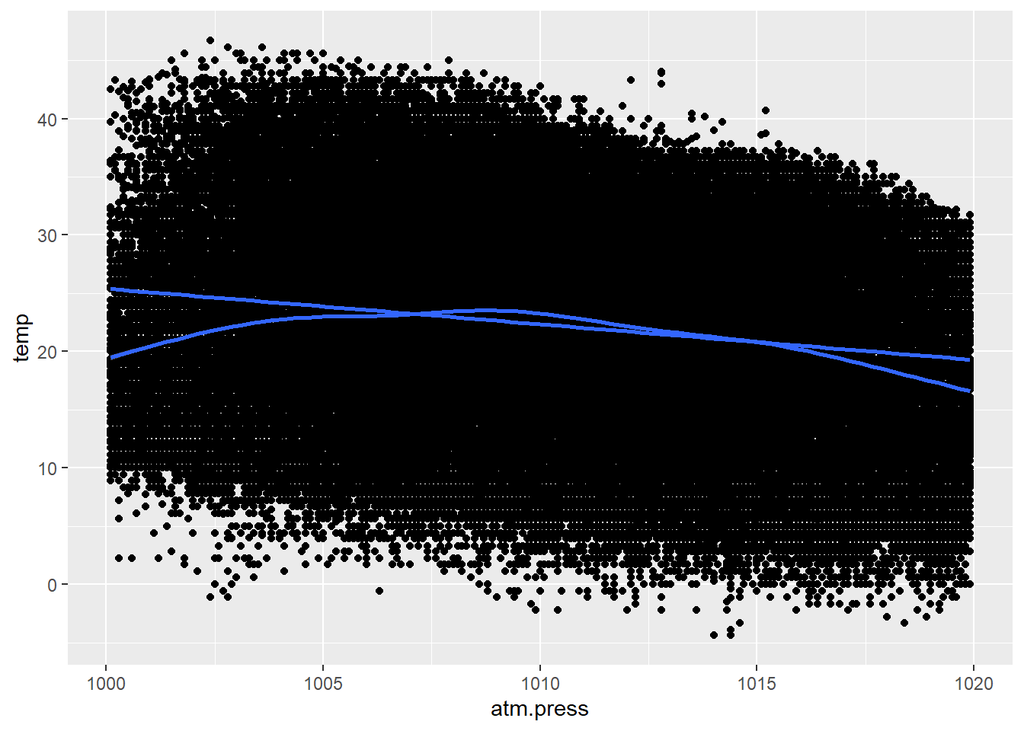

```r
ggplot(met, aes(x=atm.press, y=temp)) +
  geom_point() +
  geom_smooth(method=lm) +
  geom_smooth()
```

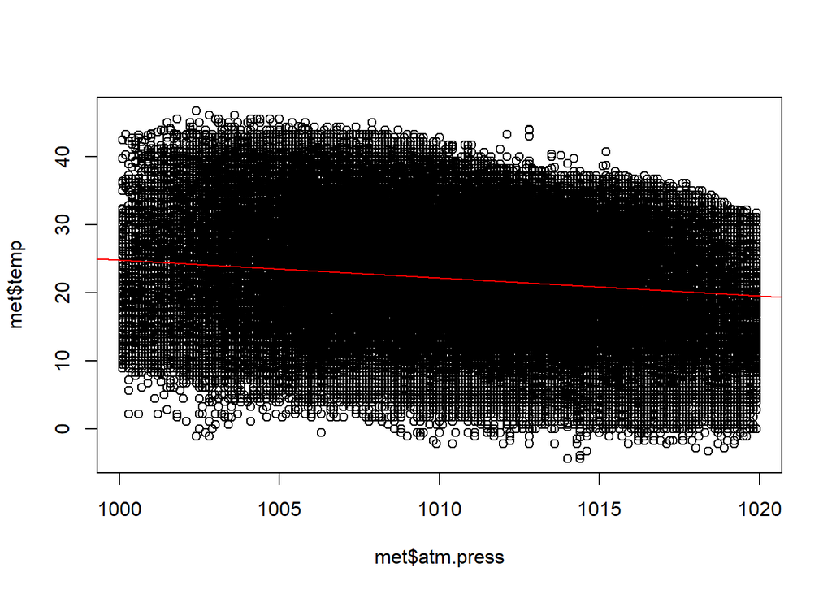

```r
plot(met$atm.press, met$temp)
abline(lreg, col="red")
```

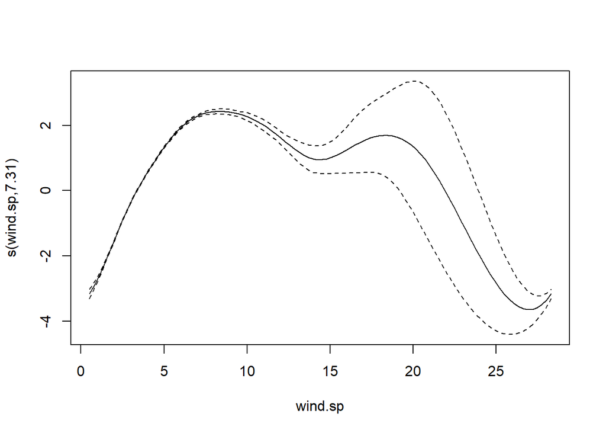

```r
plot(sp)
```

The spline regression is a better model since it has a higher adjusted R squared.

## Deliverables

- .Rmd file (this file)
- link to the .md file (with all outputs) in your GitHub repository